# PML_Assignment_part1

Ilya Zemskov

19OCT2015

# Weight Lifting Exersize Research

The puprose of this research is to analize data about Weight Lifting Exercise from http://groupware.les.inf.puc-rio.br/har and deduce wether subjects did Exercises correct or incorrect. Data was recieved from the accelerometers on the belt, forearm, arm, and dumbell of 6 participants.

## Initializing environment

```r
train <- read.csv("pml-training.csv")
test <- read.csv("pml-testing.csv")
library(caret)
```

```r
library(ggplot2)
library(Amelia)
```

## Preparing data

Since there are many variables in the dataset (160), let’s first try to reduce their quantity with those, whose variance is near-zero.

```r
nzv <- nearZeroVar(train[, 1:159])
train_nonzv <- train[, -nzv]
```

The size of the remaining dataset is:

```
## [1] 19622   100
```

Let’s have a look at the map of NA’s vs other values of the variables.

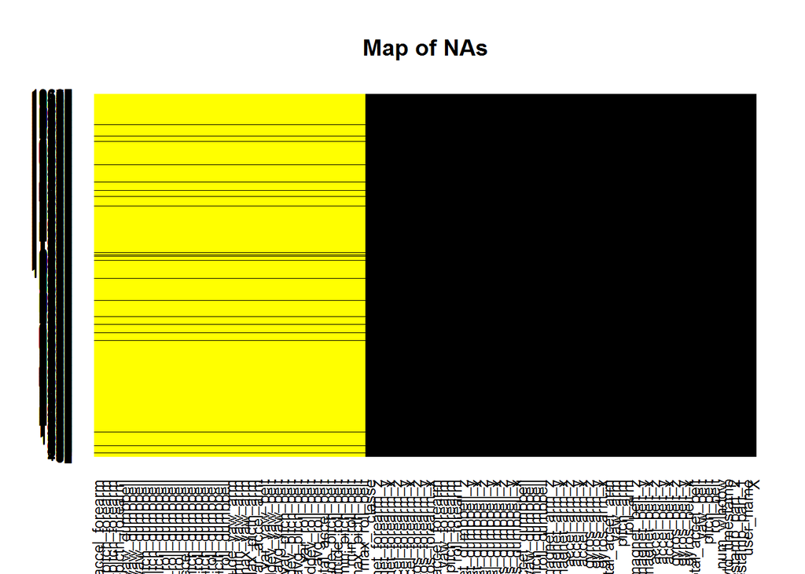

```r
missmap(train_nonzv, main="Map of NAs", col=c("yellow", "black"), legend=FALSE)
```

From the map of NAs we can see that there is still many variables with the most values equal to ‘NA’

```r
findNAColumns <- function(x) {
  flag = 0

  countNA <- sum(is.na(x))
  na_ratio <- countNA/length(x)
  # print(na_ratio, zero.print = ".")
  if (na_ratio > 0.9) {
    flag = 1
  }
  flag
}
# Applying our function to the train_nonzv dataset
isTotalNa <- sapply(train_nonzv[, 1:99], findNAColumns)
# Selectin columns from train_nonzv, which contains NA values less then on 90%
train_nonzv_nona <- train_nonzv[, -which(as.logical(isTotalNa))]
```

Reapeting the mismap function on a new dataset…

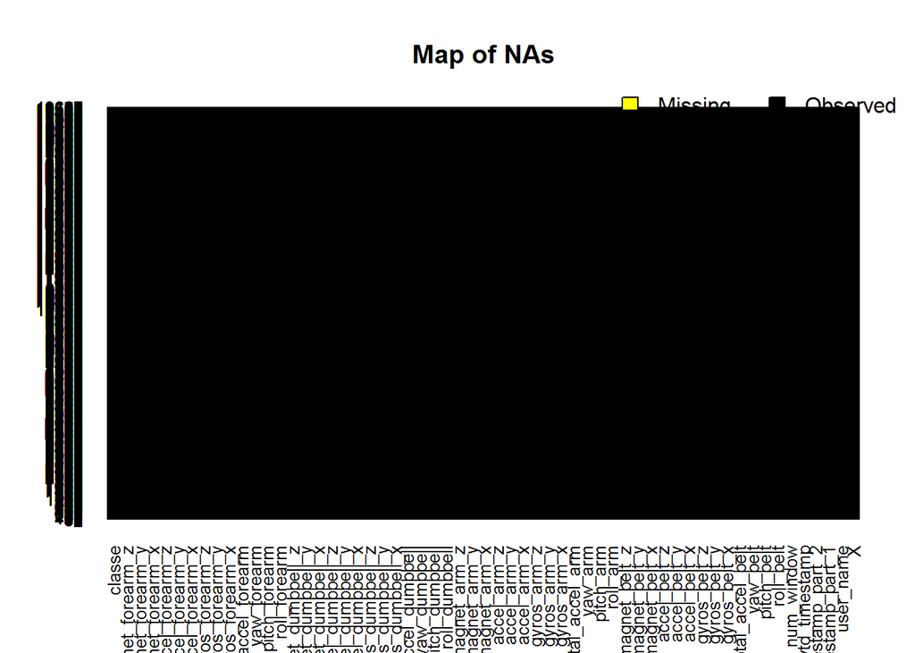

```r
missmap(train_nonzv_nona, main="Map of NAs", col=c("yellow", "black"), legend=TRUE)
```

Now variables contain only minimum NAs Now, after some predictor reduction let’s look is there any correlated predictors.

```r
train_for_cor <- train_nonzv_nona[, 5:58]
train_for_cor <- train_for_cor[, which(sapply(train_for_cor, is.numeric))]
corMatrix <- cor(train_for_cor)
# finding correlated predictors
```

Summary of the correation matrix

```r
summary(corMatrix[upper.tri(corMatrix)])
```

```
##     Min.  1st Qu.   Median     Mean  3rd Qu.     Max.
## -0.99200 -0.10710  0.00214  0.00217  0.09192  0.98090
```

```r
highlyCorPredictors <- findCorrelation(corMatrix, cutoff = 0.75)
nocor <- train_for_cor[, -highlyCorPredictors]
```

```r
corMatrix_new <- cor(nocor)
```

```r
combo_info <- findLinearCombos(nocor)
```

```r
result_train <- cbind(nocor[, 2:33], train$classe)
colnames(result_train)[33] <- "classe"
```

## Fitting the model

First I split training set ‘result_train’ on two smaller training sets to be able to estimate out-of-sample error

```r
set.seed(111)
inTrain <- createDataPartition(y=result_train$classe, p=0.7, list=F)
rtrain1 <- result_train[inTrain, ]
rtrain2 <- result_train[-inTrain, ]
```

Let’t try the ‘Random Forest’ metod tot rain out algorithm

```r
# use 3-fold CV to select optimal tuning parameters
fitControl <- trainControl(method="cv", number=3, verboseIter=F)

# fitting the model for training set
fit <- train(classe ~ ., data=rtrain1, method="rf", trControl=fitControl)
```

Now I use my model to predict the classe values in the validation dataset rtrain2

```r
predict2 <- predict(fit, newdata = rtrain2)

# show confusionMatrix
confusionMatrix(rtrain2$classe, predict2)
```

```
## Confusion Matrix and Statistics
##
##           Reference
## Prediction    A    B    C    D    E
##          A 1670    2    1    0    1
##          B    2 1127   10    0    0
##          C    0    3 1020    3    0
##          D    0    0   19  944    1
##          E    0    0    0    4 1078
##
## Overall Statistics
##
##                Accuracy : 0.9922
##                  95% CI : (0.9896, 0.9943)
##     No Information Rate : 0.2841
##     P-Value [Acc > NIR] : < 2.2e-16
##
##                   Kappa : 0.9901
##  Mcnemar's Test P-Value : NA
##
## Statistics by Class:
##
##                      Class: A Class: B Class: C Class: D Class: E
## Sensitivity            0.9988   0.9956   0.9714   0.9926   0.9981
## Specificity            0.9991   0.9975   0.9988   0.9959   0.9992
## Pos Pred Value         0.9976   0.9895   0.9942   0.9793   0.9963
## Neg Pred Value         0.9995   0.9989   0.9938   0.9986   0.9996
## Prevalence             0.2841   0.1924   0.1784   0.1616   0.1835
## Detection Rate         0.2838   0.1915   0.1733   0.1604   0.1832
## Detection Prevalence   0.2845   0.1935   0.1743   0.1638   0.1839
## Balanced Accuracy      0.9989   0.9965   0.9851   0.9943   0.9987
```

## Retraining algorithm on the full training dataset

```r
fit_full <- train(classe ~ ., data=result_train, method="rf", trControl=fitControl)
```

## Predict the values of the classe variale for the test dataet

```r
# preparing test

# excluding near zero variance vars
test_nonzv <- test[, -nzv]

# excluding NA vars
isTotalNa_test <- sapply(test_nonzv[, 1:99], findNAColumns)
test_nonzv_nona <- test_nonzv[, -which(as.logical(isTotalNa_test))]

#excluding corelated vars
test_for_cor <- test_nonzv_nona[, 5:58]
test_for_cor <- test_for_cor[, which(sapply(test_for_cor, is.numeric))]
nocor_test <- test_for_cor[, -highlyCorPredictors]

# resulting test set
result_test <- nocor_test[, 2: 33]

# making a prediction
predict_for_test <- predict(fit_full, newdata = result_test)

# converting predictions to character format
predict_for_test_ch <- as.character(predict_for_test)
```

# Writing results

```r
# create function to write predictions to files
pml_write_files <- function(x) {
    n <- length(x)
    for(i in 1:n) {
        filename <- paste0("problem_id_", i, ".txt")
        write.table(x[i], file=filename, quote=F, row.names=F, col.names=F)
    }
}

# create prediction files to submit
pml_write_files(predict_for_test_ch)
```